# IODS course project

Eric Coles

## Chapter 1

The three main themes of this course are; Open Data, Open Science, and Data Science. Open Data allows for the sharing of data between researchers in all fields. The course will teach how to use open data sets from various sources and how to analyse them in different ways as well as how to intepret the data.

Open Science allows for researchers to show and have their data reproduced by others using the same openly available software tools and methods. This course will teach students how to use these openly available software tools and methods.

Data Science falls into the realm of statistics. This course involves coding, programming, modeling, visualizing and analysing.

I am very excited to learn R Progamming and be guided through these themes of Open Data, Open Science, and Data Science :)

https://github.com/Ericcoles/IODS-project

# Regression and model validation

# 1. Reading and checking the data

Dataset with the variables `gender`, `age`, attitude`,`deep`,`stra`,`surf`and points created by combining questions in the`learning2014` data, as defined in the datacamp exercises. Scaled all combination variables to the original scales by taking the mean. Excluded observations where the exam points variable is zero. The dataset has 166 observations and 7 variables.

```r
learning2014<- read.csv("/Users/eric/Documents/GitHub/IODS-project/data/learning2014.csv")
str(learning2014)
```

```
## 'data.frame':    166 obs. of  7 variables:
##  $ gender  : Factor w/ 2 levels "F","M": 1 2 1 2 2 1 2 1 2 1 ...
##  $ age     : int  53 55 49 53 49 38 50 37 37 42 ...
##  $ Attitude: int  37 31 25 35 37 38 35 29 38 21 ...
##  $ deep    : num  3.58 2.92 3.5 3.5 3.67 ...
##  $ stra    : num  3.38 2.75 3.62 3.12 3.62 ...
##  $ surf    : num  2.58 3.17 2.25 2.25 2.83 ...
##  $ points  : int  25 12 24 10 22 21 21 31 24 26 ...
```

```r
dim(learning2014)
```

```
## [1] 166   7
```

# Installed the packages ggplot2 and GGally in Rstudio

```r
library(ggplot2)
library(GGally)
```

# 2.Graphical overview of the data and summaries of the variables in the data.

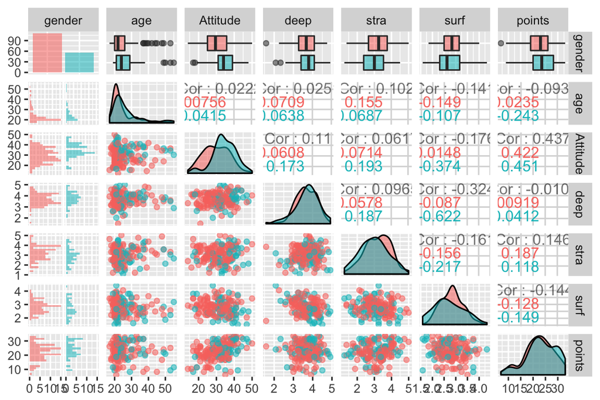

```r
p1 <- ggpairs(learning2014, mapping = aes(col=gender,alpha=0.3), lower=list(combo = wrap("facethist", bins = 20)))
p1
```

Genders are shown in Blue(males) and Pink(females). One can see cleary that points and Attitude has the highest correlation values in both males and females.This suggests that one’s attidude could effect the points one receives. The lowest correlation values for women are seen in Attitude and age,0.00756, suggesting that attitude and age do not have a relationship among women in the study sample. However men had a much higher correlation value in Attiude and age,0.0415, suggesting that there is more of a relationship between Attitude and age among men than in women in the study sample.

# 3. Regression Model

Here I chose three variables as explanatory variables and fit a regression model where exam points is the target (dependent) variable. Showing a summary of the fitted model, commenting and interpreting the results. As well as explaining and interpreting the statistical test related to the model parameters.

```r
regression_model <- lm(points ~ Attitude + stra + age, data = learning2014)
summary(regression_model)
```

```
##
## Call:
## lm(formula = points ~ Attitude + stra + age, data = learning2014)
##
## Residuals:
##      Min       1Q   Median       3Q      Max
## -18.1149  -3.2003   0.3303   3.4129  10.7599
##
## Coefficients:
##             Estimate Std. Error t value Pr(>|t|)
## (Intercept) 10.89543    2.64834   4.114 6.17e-05 ***
## Attitude     0.34808    0.05622   6.191 4.72e-09 ***
## stra         1.00371    0.53434   1.878   0.0621 .
## age         -0.08822    0.05302  -1.664   0.0981 .
## ---
## Signif. codes:  0 '***' 0.001 '**' 0.01 '*' 0.05 '.' 0.1 ' ' 1
##
## Residual standard error: 5.26 on 162 degrees of freedom
## Multiple R-squared:  0.2182, Adjusted R-squared:  0.2037
## F-statistic: 15.07 on 3 and 162 DF,  p-value: 1.07e-08
```

`Attitude`, `stra`, and `age` are the independent variables in the regression model and the variable points is the dependent variable. From the t value as well as the p-value Pr, it shows that the variables `stra` and `age` are not statistically significant. However, it is shown from the data analysis that the relationship between `points` and `Attitude` is significant from the P-value of 4.72e-09 and a high t-value of 6.191.

# 4.Fitted Regression Model

```r
regression_model_fit <- lm(points ~ Attitude, data = learning2014)
summary(regression_model_fit)
```

```
##
## Call:
## lm(formula = points ~ Attitude, data = learning2014)
##
## Residuals:
##      Min       1Q   Median       3Q      Max
## -16.9763  -3.2119   0.4339   4.1534  10.6645
##
## Coefficients:
##             Estimate Std. Error t value Pr(>|t|)
## (Intercept) 11.63715    1.83035   6.358 1.95e-09 ***
## Attitude     0.35255    0.05674   6.214 4.12e-09 ***
## ---
## Signif. codes:  0 '***' 0.001 '**' 0.01 '*' 0.05 '.' 0.1 ' ' 1
##
## Residual standard error: 5.32 on 164 degrees of freedom
## Multiple R-squared:  0.1906, Adjusted R-squared:  0.1856
## F-statistic: 38.61 on 1 and 164 DF,  p-value: 4.119e-09
```

Both ‘stra’ and ‘age’ did not have a statistically significant relationship with the dependent variable, and in this model they were removed.

The Attitude variable had a high t-value of 6.214 and a significant p-value of 4.12e-09.

From the data it is shown that the Multiple R-squared is 0.1906 and the Adjusted R-squared value is 0.1856.

R-squared cannot be used to determine whether the coefficient estimates and predictions are biased, which is why you must assess the residual plots. [Reference](http://statisticsbyjim.com/regression/interpret-r-squared-regression/)

R-squared does not indicate if a regression model provides an adequate fit to your data. A good model can have a low R2 value. On the other hand, a biased model can have a high R2 value.[Reference](http://statisticsbyjim.com/regression/interpret-r-squared-regression/)

# 5.Graphical model validation

Residuals vs Fitted values, Normal QQ-plot and Residuals vs Leverage.

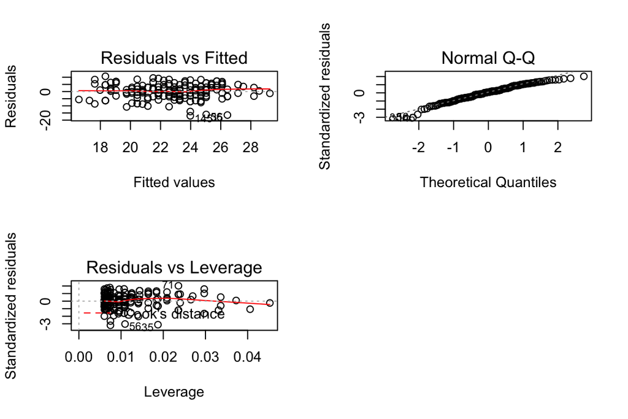

```r
par(mfrow = c(2,2))
plot(regression_model_fit, which = c(1, 2, 5))
```

## The Residuals vs. Fitted plot

It is a scatter plot of residuals on the y axis and fitted values (estimated responses) on the x axis. The plot is used to detect non-linearity, unequal error variances, and outliers.

The residuals “bounce randomly” around the 0 line. This suggests that the assumption that the relationship is linear is reasonable.

The residuals roughly form a “horizontal band” around the 0 line. This suggests that the variances of the error terms are equal.

Three of the residuals(145,56,35) “stands out” from the basic random pattern of residuals. This suggests that there are outliers.

## The Normal Q-Q Plot

The quantile quantile (qq) plot is a graphical technique for determining if two data sets come from populations with a common distribution. A q-q plot is a plot of the quantiles of the first data set against the quantiles of the second data set.

These two batches do appear to have come from populations with a common distribution as the majority of the values fall on the same line. This also contains outliers (145,56,35)

# Chapter3

I loaded “GGally”,“ggplot2”and “tidyr” libaries for this assignment.

```r
library(GGally)
library(ggplot2)
library(tidyr);
```

```r
url<-"http://s3.amazonaws.com/assets.datacamp.com/production/course_2218/datasets/alc.txt"
```

Data Set Information: The data set focuses on student achievement in secondary education of two portuguese schools. The data set includes student grades, demographic information, and social and school related features. The data was collected using school reports and questionnaires. There are two datasets, math and portuguese language with grades from different grading period data; G1, G2 and G3.

Printed out the names of the variables in the data, explored their sturcture and dim.

colnames(alc) str(alc) dim(alc)

I have chosen studytime, traveltime, age and freetime. I predict that traveltime increases alcohol consumpiton. I predict that studytime has a negative correlation with high_use alcohol consumption. I predict that age is related to alchohol consumption as well as freetime.

The variable “studytime” is numeric, the variable “traveltime” is numeric, the variable “age” is an integer, and the variable “freetime” is numeric.

summary(alc$studytime) summary(alc$traveltime) summary(alc$age) summary(alc$freetime)

I graphically explored the varabiles;“high_use”,“studytime”,“traveltime”,“age”,“freetime”

I defined a regression model with the variables “high_use”,“studytime”,“traveltime”,“age”,“freetime”.

I obtain the odds ratios and their confidence intervals by taking the exponential function:

predict() the probability of high_use

probabilities <- predict(m, type = “response”)

add the predicted probabilities to ‘alc’

alc_data <- mutate(alc_data, probability = probabilities)

use the probabilities to make a prediction of high_use

alc_data <- mutate(alc_data, prediction = probability > 0.5)

see the last ten original classes, predicted probabilities, and class predictions

select(alc_data, high_use, studytime, traveltime, age, freetime) %>% tail(10)

table(high_use = alc_data$high_use, prediction = alc_data$prediction)

high_use FALSE TRUE FALSE 256 12 TRUE 96 18

# 10-fold cross-validation

loss_func <- function(class, prob) { n_wrong <- abs(class - prob) > 0.5 mean(n_wrong) } loss_func(class = alc_data$high_use, prob = alc_data$probability)

library(boot) cv <- cv.glm(data=alc_data, cost=loss_func, glmfit=m, K=10) cv$delta[1]

# Super-Bonus

m2 <- glm(high_use ~ high_use + studytime + traveltime + age + freetime + health +famrel + G1 +G2 + G3, data = alc, family = “binomial”) probabilities2 <- predict(m2, type = “response”) alc_data2 <- select(alc,c(“high_use”,“studytime”,“traveltime”,“age”,“freetime”,“health”,“famrel”,“G1”,“G2”,“G3”)) alc_data2<- mutate(alc_data2, probability2 = probabilities2) alc_data2 <- mutate(alc_data2, prediction2 = probability2 > 0.5) loss_func <- function(class, prob) { n_wrong <- abs(class - prob) > 0.5 mean(n_wrong) } loss_func(class = alc_data2$high_use, prob = alc_data2$probability2) cv2 <- cv.glm(data = alc_data2, cost = loss_func, glmfit = m2, K = 10) cv2$delta[1]